# Making a linked map and time series plot

Interactive graphics can be useful because they make it possible to look at the data in multiple of ways on-the-fly. This is especially important for spatio-temporal data, where we would like to interactively connect spatial and temporal displays. This vignette will show you how to make an interactive graphic with a cubble object. We will be using `crosstalk::bscols()` to create a linked interactive plot of an Australia map, made with leaflet, and a ggplot-turned plotly time series plot:

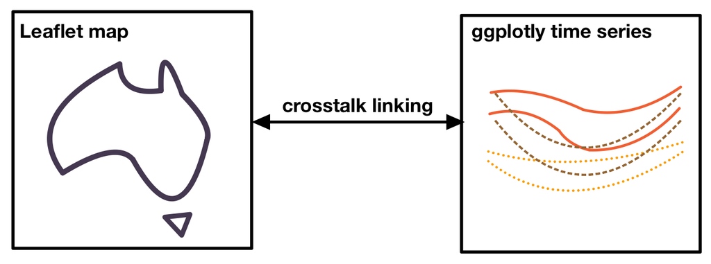

This vignette assumes you have gone through Get started and are familiar with basic data wrangling in cubble with `face_temporal()` and `face_spatial()`.

# Variation of the diurnal temperature range in Australia

```r
(clean <- climate_subset |>
  face_temporal() |>
  mutate(month = lubridate::month(date, label = TRUE, abbr = TRUE)) |>
  group_by(month) |>
  summarise(
    tmax = mean(tmax, na.rm = TRUE),
    tmin = mean(tmin, na.rm = TRUE),
    diff = mean(tmax - tmin, na.rm = TRUE)
    ) |>
  face_spatial() |>
  mutate(temp_diff_var = var(ts$diff, na.rm = TRUE)))
```

```
#> # cubble:   id [30]: nested form
#> # bbox:     [114.09, -41.88, 152.87, -11.65]
#> # temporal: month [ord], tmax [dbl], tmin [dbl], diff [dbl]
#>    id            lat  long  elev name              wmo_id ts       temp_diff_var
#>    <chr>       <dbl> <dbl> <dbl> <chr>              <dbl> <list>           <dbl>
#>  1 ASN00003057 -16.5  123.   7   cygnet bay         94201 <tibble>         8.27
#>  2 ASN00005007 -22.2  114.   5   learmonth airport  94302 <tibble>         1.80
#>  3 ASN00005084 -21.5  115.   5   thevenard island   94303 <tibble>         0.389
#>  4 ASN00010515 -32.1  117. 199   beverley           95615 <tibble>         5.08
#>  5 ASN00012314 -27.8  121. 497   leinster aero      95448 <tibble>         0.868
#>  6 ASN00014401 -11.7  133.  19.2 warruwi            94139 <tibble>         0.662
#>  7 ASN00014703 -15.7  137.  12.2 centre island      94248 <tibble>         0.314
#>  8 ASN00017123 -28.1  140.  37.8 moomba airport     95481 <tibble>         1.36
#>  9 ASN00018201 -32.5  138.  14   port augusta aero  95666 <tibble>         2.56
#> 10 ASN00022841 -35.7  138.   5   kingscote aero     95807 <tibble>         3.72
#> # … with 20 more rows
```

# Linking with crosstalk

Crosstalk accepts linking between multiple data objects in the same group. Here we create two SharedData objects (one using the nested form and another using the long form), with `id` as the key and give them the same group name (`group = "cubble"`):

```r
nested <- clean %>% SharedData$new(~id, group = "cubble")
long <- clean |>
  face_temporal() |>
  unfold(temp_diff_var) |>
  arrange(temp_diff_var) %>%
  SharedData$new(~id, group = "cubble")
```

# Create maps with leaflet

A basic leaflet map of stations can be created with an underlying map tile (`addTiles()`) and points to represent stations (`addCircleMarkers()`):

```
leaflet(nested, width = 300, height = 300) |>
  addTiles() |>
  addCircleMarkers()
```

Applying color to the stations requires mapping the variable in the data to the color palette. Here the numerical variable `temp_diff_var` is mapped onto a sequential color palette, Rocket, with some fine-tuning using `colorNumeric()`. A popup of station names can be added with the `popup` argument in `addCircleMarkers()` and a `~` is needed when specifying variable name in leaflet syntax:

```r
domain <- clean$temp_diff_var
pal <- colorNumeric(
  colorspace::sequential_hcl(
    "Rocket",  n = 7, cmax = 90, rev = TRUE, c2 = 40, l2= 85, c1 = 20, l1 = 30),
  domain = domain)

map <- leaflet(nested, width = 300, height = 300) |>
  addTiles() |>
  addCircleMarkers(color = ~pal(domain), group = "a", radius = 0.1,
                   popup = ~name, fillOpacity = 1, opacity = 1)
```

# Time series plot with plotly

```r
ts_static <- long %>%
  ggplot(aes(x = month, group = id,
         fill = temp_diff_var, color = temp_diff_var
         )) +
  geom_ribbon(aes(ymin = tmin, ymax = tmax), size = 0.1, alpha = 0.3) +
  # geom_point(aes(y = tmax), size = 0.1) +
  # geom_point(aes(y = tmin), size = 0.1) +
  colorspace::scale_fill_continuous_sequential(
    "Rocket",  n_interp = 7, cmax = 90, rev = TRUE,
    c2 = 40, l2= 85, c1 = 20, l1 = 30, name = "Var. temp. diff.") +
  colorspace::scale_colour_continuous_sequential(
    "Rocket",  n_interp = 7, cmax = 90, rev = TRUE,
    c2 = 40, l2= 85, c1 = 20, l1 = 30, name = "Var. temp. diff.") +
  labs(x = "Month", y = "Temperature") +
  theme_bw() +
  theme(
    panel.grid.major = element_blank(),
    legend.position = "bottom"
    )
```

The static ggplot object can be turned into a plotly object with `ggplotly()` and `plotly::highlight()` enable the selection with box or lasso (`on = "plotly_selected"`):

```r
ts_interactive <- ggplotly(ts_static, width = 600, height = 300) %>%
    highlight(on = "plotly_selected", opacityDim = 0.012)
```

# Assemble into a linked plot

`crosstalk::bscols()` can be thought of as the `patchwork` for interactive graphics, which arranges multiple interactive graphics in columns.

```r
bscols(map, ts_interactive, widths = c(4, 6))
```

Below is a screenshot of the full graphics:

[figure not shown]

# Making selection to see the linking

The selection built in the linked plot goes in both directions. In the screenshot below, a lasso selection is made on the time series and this links to cygnet bay on the northwest coastline of Australia. The area has a larger temperature range in July than in the summer period (December - February).

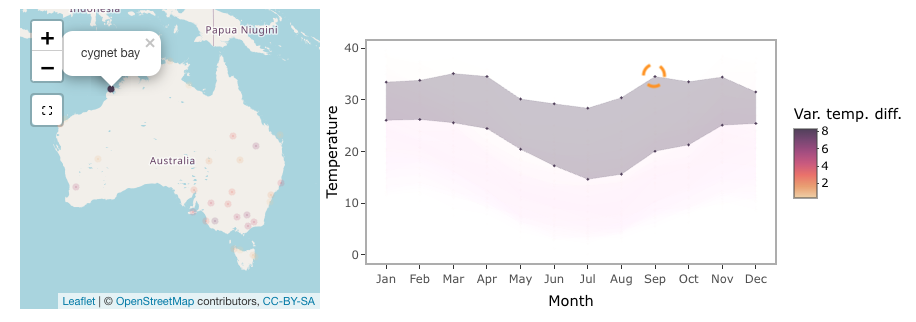

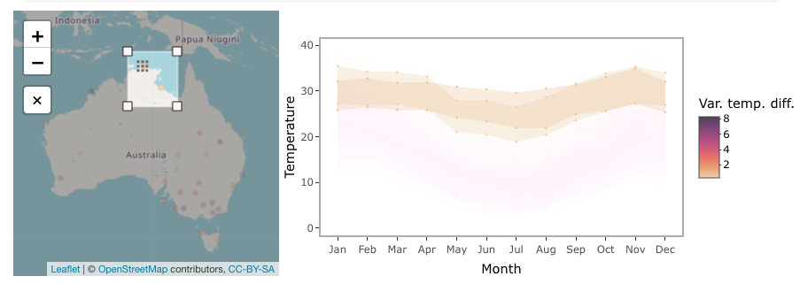

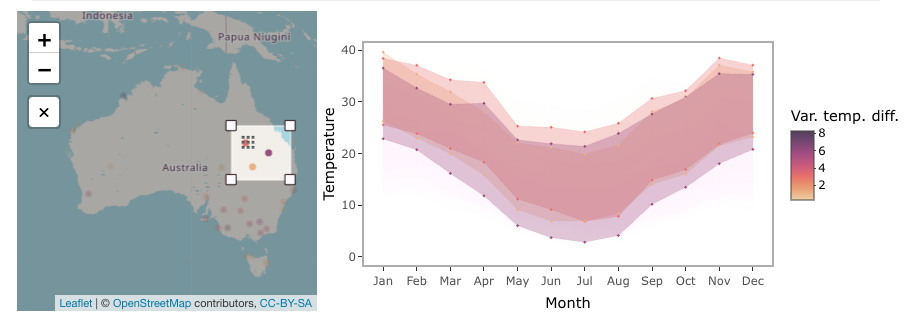

Now it is your time to view the tooltip on the map and use the selection to explore weather patterns in Australia!